## Columbia University

### ECBM E4040 Neural Networks and Deep Learning

# Assignment 2: Multilayer Perceptron (MLP)

This is the second part of the assignment. You will get to know how to build basic fully connected neural network.

```python
# Import modules
from __future__ import print_function
import tensorflow as tf
import numpy as np
import time
import os
import matplotlib.pyplot as plt
import pickle
import warnings
warnings.filterwarnings('ignore')
from utils.cifar_utils import load_data

# Plot configurations
%matplotlib inline

# Notebook auto reloads code. (Ref: http://stackoverflow.com/questions/1907993/autoreload-of-modules-in-ipython)
%load_ext autoreload
%autoreload 2
```

## Load Data

```python
# Load the raw CIFAR-10 data.
X_train, y_train, X_test, y_test = load_data()

# Data organizations:
# Train data: 49000 samples from original train set: 1~49,000
# Validation data: 1000 samples from original train set: 49,000~50,000
# Test data: 10000 samples from original test set: 1~10,000
# Development data (for gradient check): 100 from the train set: 1~49,000
num_training = 49000
num_validation = 1000
num_dev = 100

X_val = X_train[-num_validation:, :]
y_val = y_train[-num_validation:]

mask = np.random.choice(num_training, num_dev, replace=False)
X_dev = X_train[mask]
y_dev = y_train[mask]

X_train = X_train[:num_training, :]
y_train = y_train[:num_training]

# Preprocessing: subtract the mean value across every dimension for training data
mean_image = np.mean(X_train, axis=0)

X_train = X_train.astype(np.float32) - mean_image.astype(np.float32)
X_val = X_val.astype(np.float32) - mean_image
X_test = X_test.astype(np.float32) - mean_image
X_dev = X_dev.astype(np.float32) - mean_image

print(X_train.shape, X_val.shape, X_test.shape, X_dev.shape)
print('Train data shape: ', X_train.shape)
print('Train labels shape: ', y_train.shape)
print('Validation data shape: ', X_val.shape)
print('Validation labels shape: ', y_val.shape)
print('Test data shape: ', X_test.shape)
print('Test labels shape: ', y_test.shape)
print('Development data shape:', X_dev.shape)
print('Development data shape', y_dev.shape)
```

```
(49000, 3072) (1000, 3072) (10000, 3072) (100, 3072)
Train data shape:  (49000, 3072)
Train labels shape:  (49000,)
Validation data shape:  (1000, 3072)
Validation labels shape:  (1000,)
Test data shape:  (10000, 3072)
Test labels shape:  (10000,)
Development data shape: (100, 3072)
Development data shape (100,)
```

## Part 1: Basic layers

In this part, all the functions will be created from scratch using numpy for better understanding. (In the next task, you will be introduced to built in layers from tensorflow.)

### Create basic layer functions

Complete functions **affine_forward**, **affine_backward**

```python
from builtins import range
import numpy as np

def affine_forward(x, w, b):
    """
    Computes the forward pass for an affine function.

    The input x has shape (N, d_1, ..., d_k) and contains a minibatch of N
    examples, where each example x[i] has shape (d_1, ..., d_k). We will
    reshape each input into a vector of dimension D = d_1 * ... * d_k, and
    then transform it to an output vector of dimension M.

    Inputs:
    - x: a numpy array containing input data, of shape (N, d_1, ..., d_k)
    - w: a numpy array of weights, of shape (D, M)
    - b: a numpy array of biases, of shape (M,)

    Returns a tuple of:
    - out: output, of shape (N, M)
    """
    # Implement the affine forward pass. Store the result in 'out'. You
    # will need to reshape the input into rows.

    x = x.reshape(x.shape[0],-1)
    out = np.matmul(x,w) + b

    return out


def affine_backward(dout, x, w, b):
    """
    Computes the backward pass of an affine function.

    Inputs:
    - dout: upstream derivative, of shape (N, M)
    - x: input data, of shape (N, d_1, ... d_k)
    - w: weights, of shape (D, M)
    - b: bias, of shape (M,)

    Returns a tuple of:
    - dx: gradient with respect to x, of shape (N, d1, ..., d_k)
    - dw: gradient with respect to w, of shape (D, M)
    - db: gradient with respect to b, of shape (M,)
    """

    dx = None #initialize
    dw = None
    db = None

    dx = np.matmul(dout, w.T).reshape(x.shape)
    dw = np.matmul(x.reshape(x.shape[0], -1).T, dout)
    db = np.sum(dout, axis=0)


    return dx, dw, db
```

**NOTE**: Please do not change the code in the cell below, The cell below will run correctly if your code is right.

```python
# THE FOLLOWING CODE IS JUST FOR CHECKING.     #
# NO NEED TO CHANGE IT.                        #

from utils.layer_funcs import affine_forward
from utils.layer_funcs import affine_backward

# generate data for checking
x = X_dev
w = np.random.rand(x.shape[1],100)
b = np.random.rand(100)
dout = np.ones((x.shape[0],100))

## Affine function -- H = W*X + b
out = affine_forward(x, w, b)
dx, dw, db = affine_backward(dout, x, w, b)

## check by tfe.gradients_function()
x_tf = tf.Variable(x, name='x')
w_tf = tf.Variable(w, name='w')
b_tf = tf.Variable(b, name='b')

def affine_layer(x, w, b):
    return tf.matmul(x, w) + b

with tf.GradientTape() as tape:
    tape.watch(w_tf)
    out_tf = affine_layer(x_tf, w_tf, b_tf)
    dx_tf, dw_tf, db_tf = tape.gradient(out_tf, (x_tf, w_tf, b_tf))

out_check = out_tf.numpy()
dx_check, dw_check, db_check = dx_tf.numpy(), dw_tf.numpy(), db_tf.numpy()

## Print validation result
print("Is out correct? {}".format(np.allclose(out, out_check)))
print("Is dx correct? {}".format(np.allclose(dx, dx_check)))
print("Is dw correct? {}".format(np.allclose(dw, dw_check)))
print("Is db correct? {}".format(np.allclose(db, db_check)))
```

```
Is out correct? True
Is dx correct? True
Is dw correct? True
Is db correct? True
```

Complete functions **relu_forward**, **relu_backward**

```python
def relu_forward(x):
    """
    Computes the forward pass for rectified linear units (ReLUs).

    Input:
    - x: inputs, of any shape

    Returns a tuple of:
    - out: output, of the same shape as x
    """
    # Implement the ReLU forward pass.


    out = np.maximum(0, x)


    return out


def relu_backward(dout, x):
    """
    Computes the backward pass for rectified linear units (ReLUs).

    Input:
    - dout: upstream derivatives, of any shape

    Returns:
    - dx: gradient with respect to x
    """

    # Implement the ReLU backward pass.

    relu_grad = x > 0 #boolean
    dx = dout * relu_grad


    return dx
```

**NOTE**: Please do not change the code in the cell below, The cell below will run correctly if your code is right.

```python
# THE FOLLOWING CODE IS JUST FOR CHECKING.     #
# NO NEED TO CHANGE IT.                        #

from utils.layer_funcs import relu_forward
from utils.layer_funcs import relu_backward

## Activation layers -- Here we introduce ReLU activation function
## since it is the most commonly used in computer vision problems.
## However, you can also try to implement
## other activation functions like sigmoid, tanh etc.
x = X_dev
dout = np.ones(x.shape)
## ReLU
out = relu_forward(x)
dx = relu_backward(dout, x)

## check by tf.GradientTape.gradients()
x_tf = tf.Variable(x, name='x')
with tf.GradientTape() as tape:
    tape.watch(x_tf)
    out_tf = tf.nn.relu(x_tf)
    grad_gt = tape.gradient(out_tf, x_tf)

out_check = out_tf.numpy()
dx_check = grad_gt.numpy()
## Print validation result
print("Is out correct? {}".format(np.allclose(out, out_check)))
print("Is dx correct? {}".format(np.allclose(dx, dx_check)))
```

```
Is out correct? True
Is dx correct? True
```

Complete functions **softmax_loss**

```python
# Stable
# def softmax(X):
#     exps = np.exp(X - np.max(X))
#     return exps / np.sum(exps)

def softmax(z):
    assert len(z.shape) == 2 #Test if a condition returns True
    s = np.max(z, axis=1)
    s = s[:, np.newaxis] # (z.shape[0], 1)
    e_x = np.exp(z - s) #  improve the numerical stability
    # see https://stats.stackexchange.com/questions/338285/how-does-the-subtraction-of-the-logit-maximum-improve-learning
    div = np.sum(e_x, axis=1)
    div = div[:, np.newaxis]
    return e_x / div

def softmax_loss(x, y):
    """
    Softmax loss function, vectorized version.
    y_prediction = argmax(softmax(x))

    Inputs:
    - x: (float) a tensor of shape (N, #classes)
    - y: (int) ground truth label, a array of length N

    Returns:
    - loss: the cross-entropy loss
    - dx: gradients wrt input x
    """
    # Initialize the loss.
    loss = 0.0
    dx = np.zeros_like(x)

    # You can use the previous softmax loss function here.
    # Hint: Be careful on overflow problem

    # First transform the y into onehot
#     num_classes = x.shape[1]
#     one_hot_y = np.zeros(x.shape[0], num_classes)
#     for idx, item in enumerate(y):
#         one_hot_y[idx, item] = 1

    # Calculate the softmax of x
    prob = softmax(x)
#     print("prob: ", prob)
    log_likelihood = -np.log(prob[range(x.shape[0]),y])
    loss = np.sum(log_likelihood) / x.shape[0]

    prob_2 = softmax(x)
    prob_2[range(x.shape[0]),y] -= 1
    dx = prob_2/x.shape[0]

    return loss, dx
```

**NOTE**: Please do not change the code in the cell below, The cell below will run correctly if your code is right.

```python
# THE FOLLOWING CODE IS JUST FOR CHECKING.     #
# NO NEED TO CHANGE IT.                        #

from utils.layer_funcs import softmax_loss

## generate some random data for testing
x = np.random.rand(100,10)
y = np.argmax(x, axis=1)

loss, dx = softmax_loss(x, y)

## check by tf.GradientTape.gradients()

x_tf = tf.Variable(x, name='x')
y_tf = tf.Variable(y, name='y')

with tf.GradientTape() as tape:
    tape.watch(x_tf)
    cross_entropy = tf.nn.softmax_cross_entropy_with_logits(logits= x_tf, labels=tf.one_hot(y_tf,10))
    loss_tf = tf.reduce_mean(cross_entropy)
    dx_tf = tape.gradient(loss_tf, x_tf)

loss_check = loss_tf.numpy()
dx_check = dx_tf.numpy()
## Print validation result
print("Is loss correct? {}".format(np.allclose(loss, loss_check)))
print("Is dx correct? {}".format(np.allclose(dx, dx_check)))
```

```
Is loss correct? True
Is dx correct? True
```

### Create a single layer

Now try to combine an affine function and a nonlinear activation function into a single fully-connected layer. Edit the code in ./utils/layer_utils.py

$$\mathbf{O} = activation(\mathbf{W} \times \mathbf{X} + \mathbf{b})$$

For this assignment, you need to create two types of layers as below. You can get started with the skeleton code in ./utils/layer_utils.py. The basic class structure has been provided, and you need to fill in the "TODO" part(s).

- DenseLayer -- Affine transform >> ReLU

  ```
  Class DenseLayer:
    Variables: weights, bias
    Functions:
        __init__: given (input_dim, output_dim, weight_scale)
        feedforward: TODO
        backforward: TODO
  ```

- AffineLayer -- Affine transform and the class structure is similar to DenseLayer

Complete function **AffineLayer** in **./utils/layer_utils.py**

```python
class FullyConnectedLayer(object):
    def reset_layer(self, weight_scale=1e-2):
        """
        Reset weight and bias.

        Inputs:
        - weight_scale: (float) define the scale of weights
        """
        input_dim = self.input_dim
        hidden_dim = self.output_dim

        W = np.random.rand(input_dim, output_dim)
        b = np.zeros(output_dim)
        self.params = [W, b]

    def update_layer(self, params):
        """
        Update weight and bias
        """
        self.params = params

class AffineLayer(FullyConnectedLayer):
    """
    An affine hidden layer performs an affine transform.
    """
    def __init__(self, input_dim, output_dim=100, weight_scale=1e-2):
        """
        Initialize weight W with random value and
        bias b with zero.

        Inputs:
        - input_dim: (int) the number of input neurons,
                     like D or D1xD2x...xDn.
        - output_dim: (int) the number of hidden neurons in this layer
        """
        self.input_dim = input_dim
        self.output_dim = output_dim

        W = weight_scale*np.random.rand(input_dim, output_dim)
        b = np.zeros(output_dim)
        self.params = [W, b]

    def feedforward(self, X):
        """
        Inputs:
        - X: (float) a tensor of shape (N,D) or
             (N, D1, D2, ..., Dn).
        Returns:
        - out: output of shape (N, hidden_dim)
        """

        W, b = self.params
        ################################################
        # out = X*W + b.
        # Use functions in layer_funcs.py

        self.X = X
        out = affine_forward(x = X, w = W, b = b)
#         print(out)

        return out

    def backward(self, dout):
        """
        Inputs:
        - dout: (float) a tensor with shape (N, hidden_dim)
                Here hidden_dim denotes the number of hidden
                neurons
        Returns:
        - dX: gradients wrt intput X, shape (N, D)
        - dW: gradients wrt W, shape (D, hidden_dim)
        - db: gradients wrt b, length hidden_dim
        """
        W, b = self.params
        X = self.X

        dX = np.zeros_like(X)
        dW = np.zeros_like(W)
        db = np.zeros_like(b)
        ################################################
        # derive the gradients wrt to X, W, b    #
        # Use layer_funcs.py.                          #

        dX, dW, db = affine_backward(dout = dout, x = X, w = W, b = b)

        self.gradients = [dW, db]

        return dX
```

**NOTE**: Please do not change the code in the cell below, The cell below will run correctly if your code is right.

```python
# THE FOLLOWING CODE IS JUST FOR CHECKING.     #
# NO NEED TO CHANGE IT.                        #

from utils.layer_utils import AffineLayer

## Affine
test_affine = AffineLayer(input_dim=3072,output_dim=100)
w, b = test_affine.params

## Data for correctness check
x = X_dev
dout = np.ones((x.shape[0], 100))

out = test_affine.feedforward(x)
dx = test_affine.backward(dout)
dw, db = test_affine.gradients

## check by tf.GradientTape.gradients()
x_tf = tf.Variable(x, name='x')
w_tf = tf.Variable(w, name='w')
b_tf = tf.Variable(b, name='b')

def affine_layer(x, w, b):
    return tf.matmul(x, w) + b

with tf.GradientTape() as tape:
    tape.watch(w_tf)
    out_tf = affine_layer(x_tf, w_tf, b_tf)
    dx_tf, dw_tf, db_tf = tape.gradient(out_tf, (x_tf, w_tf, b_tf))

out_check = out_tf.numpy()
dx_check = dx_tf.numpy()
dw_check = dw_tf.numpy()
db_check = db_tf.numpy()

## Print validation result
print("Is out correct? {}".format(np.allclose(out, out_check)))
print("Is dx correct? {}".format(np.allclose(dx, dx_check)))
print("Is dw correct? {}".format(np.allclose(dw, dw_check)))
print("Is db correct? {}".format(np.allclose(db, db_check)))
```

```
Is out correct? True
Is dx correct? True
Is dw correct? True
Is db correct? True
```

Complete function **DenseLayer**

```python
class DenseLayer(FullyConnectedLayer):
    """
    A dense hidden layer performs an affine transform followed by ReLU.
    Here we use ReLU as default activation function.
    """
    def __init__(self, input_dim, output_dim=100, weight_scale=1e-2):
        """
        Initialize weight W with random value and
        bias b with zero.

        Inputs:
        - input_dim: (int) the number of input neurons,
                     like D or D1xD2x...xDn.
        - output_dim: (int) the number of hidden neurons
                      in this layer
        """
        self.input_dim = input_dim
        self.output_dim = output_dim

        W = weight_scale*np.random.rand(input_dim, output_dim)
        b = np.zeros(output_dim)
        self.params = [W, b]

    def feedforward(self, X):
        """
        Inputs:
        - X: (float) a tensor of shape (N,D) or
             (N, D1, D2, ..., Dn).
        Returns:
        - out: output of shape (N, output_dim)
        """
        ################################################
        # out = ReLU(X*W + b). Use functions in  #
        # layer_funcs.py                     #
        # Output of affine_forward is named as A
        # Output of relu_forward is named as out

        self.X = X
        W, b = self.params
        A = affine_forward(x = X, w = W, b = b)
        self.A = A
        out = relu_forward(A)


        return out

    def backward(self, dout):
        """
        Inputs:
        - dout: (float) a tensor with shape (N, hidden_dim)

        Returns:
        - dX: gradients wrt intput X, shape (N, D)
        - dW: gradients wrt W, shape (D, hidden_dim)
        - db: gradients wrt b, length hidden_dim
        """
        W, b = self.params
        X = self.X # cache input data
        A = self.A # cache intermediate affine result

        dX = np.zeros_like(X)
        dW = np.zeros_like(W)
        db = np.zeros_like(b)
        ################################################
        # derive the gradients wst to X, W, b    #
        # Use layer_funcs.py.                          #
        ################################################


        step_1 = relu_backward(dout = dout, x = A)
        dX, dW, db = affine_backward(dout = step_1, x = X, w = W, b = b)



        self.gradients = [dW, db]

        return dX
```

**NOTE**: Please do not change the code in the cell below, The cell below will run correctly if your code is right.

```python
# THE FOLLOWING CODE IS JUST FOR CHECKING.     #
# NO NEED TO CHANGE IT.                        #

## First, let's make a dense layer
from utils.layer_utils import DenseLayer

## Affine + ReLU
test_dense = DenseLayer(input_dim=3072,output_dim=100)
w, b = test_dense.params

## Data for correctness check
x = X_dev
dout = np.ones((x.shape[0], 100))

out = test_dense.feedforward(x)
dx = test_dense.backward(dout)
dw, db = test_dense.gradients

## check by tf.GradientTape.gradients()
x_tf = tf.Variable(x, name='x')
w_tf = tf.Variable(w, name='w')
b_tf = tf.Variable(b, name='b')

def dense_layer(x, w, b):
    return tf.nn.relu(tf.matmul(x, w) + b)

with tf.GradientTape() as tape:
    tape.watch(w_tf)
    out_tf = dense_layer(x_tf, w_tf, b_tf)
    dx_tf, dw_tf, db_tf = tape.gradient(out_tf, (x_tf, w_tf, b_tf))

out_check = out_tf.numpy()
dx_check = dx_tf.numpy()
dw_check = dw_tf.numpy()
db_check = db_tf.numpy()

## Print validation result
print("Is out correct? {}".format(np.allclose(out, out_check)))
print("Is dx correct? {}".format(np.allclose(dx, dx_check)))
print("Is dw correct? {}".format(np.allclose(dw, dw_check)))
print("Is db correct? {}".format(np.allclose(db, db_check)))
```

```
Is out correct? True
Is dx correct? True
Is dw correct? True
Is db correct? True
```

## Part 2: Two Layer Network

Complete the class **TwoLayerNet** in **./utils/classifiers/twolayernet.py**. Through this experiment, you will create a two-layer neural network and learn about the backpropagation mechanism. The network structure is like **input >> DenseLayer >> AffineLayer >> softmax loss >> output**. Complete "TODO" part(s).

```
Class TwoLayerNet:
    Functions:
        __init__: GIVEN
        loss: TODO - calculate cross entropy loss and gradients wst all weights and bias.
        step: TODO - a single update all weights and bias by SGD.
        predict: TODO - output result(classification accuracy) based on input data

    Variables:
        layers
```

**TODO**: Complete class **TwoLayerNet** in **./utils/classifiers/twolayernet.py**

```python
from __future__ import print_function

import numpy as np

from utils.layer_funcs import *
from utils.layer_utils import *

class TwoLayerNet(object):
    """
    A two-layer fully-connected neural network. The net has an input dimension of
    N, a hidden layer dimension of H, and performs classification over C classes.
    We train the network with a softmax loss function and L2 regularization on the
    weight matrices. The network uses a ReLU nonlinearity after the first fully
    connected layer.

    In other words, the network has the following architecture:
    input -> DenseLayer -> AffineLayer -> softmax loss -> output
    Or more detailed,
    input -> affine transform -> ReLU -> affine transform -> softmax -> output

    The outputs of the second fully-connected layer are the scores for each class.
    """

    def __init__(self, input_dim=3072, hidden_dim=200, num_classes=10, reg=0.0, weight_scale=1e-3):
        """
        Inputs:
        - reg: (float) L2 regularization
        - weight_scale: (float) for layer weight initialization
        """
        self.layer1 = DenseLayer(input_dim, hidden_dim, weight_scale=weight_scale)
        self.layer2 = AffineLayer(hidden_dim, num_classes, weight_scale=weight_scale)
        self.reg = reg
        self.velocities = None

    def loss(self, X, y):
        """
        Calculate the cross-entropy loss and then use backpropogation
        to get gradients wst W,b in each layer.

        Inputs:
        - X: input data
        - y: ground truth

        Return loss value(float)
        """
        loss = 0.0
        reg = self.reg

        ###################################################
        # Feedforward                               #

        res_1 = self.layer1.feedforward(X)
        res_2 = self.layer2.feedforward(res_1)
#         print(res_2.shape)
        loss, dx = softmax_loss(x = res_2, y = y)
#         print(loss.shape)

        # Backpropogation,here is just one dense
        # layer, it should be pretty easy

        dx = self.layer2.backward(dx)
        dx = self.layer1.backward(dx)



        # Add L2 regularization
        square_weights = np.sum(self.layer1.params[0]**2) + np.sum(self.layer2.params[0]**2)
        loss += 0.5*self.reg*square_weights
        return loss

    def step(self, learning_rate=1e-5, optim='SGD', momentum=0.5):
        """
        Use SGD to implement a single-step update to each weight and bias.
        """
        # creates new lists with all parameters and gradients
        layer1, layer2 = self.layer1, self.layer2
        params = layer1.params + layer2.params
        grads = layer1.gradients + layer2.gradients

        if self.velocities is None:
            self.velocities = [np.zeros_like(param) for param in params]

        # Add L2 regularization
        reg = self.reg
        grads = [grad + reg*params[i] for i, grad in enumerate(grads)]
        ###################################################
        #Use SGD or SGD with momentum to update
        # variables in layer1 and layer2.

#         print(len(grads))

        # Without momentum
#         for idx, _ in enumerate(params):
#             params[idx] -= learning_rate * grads[idx]

        # With momentum #preserve gradient information
        for idx, _ in enumerate(params):
            self.velocities[idx] = momentum * self.velocities[idx] + learning_rate * grads[idx]
            params[idx] = params[idx] - self.velocities[idx]




        # update parameters in layers
        layer1.update_layer(params[0:2])
        layer2.update_layer(params[2:4])

        # Python Reference, actually there is no need for this step.
        # Here add these two lines to make code more clear.
        self.layer1 = layer1
        self.layer2 = layer2


    def predict(self, X):
        """
        Return the label prediction of input data

        Inputs:
        - X: (float) a tensor of shape (N, D)

        Returns:
        - predictions: (int) an array of length N
        """
        predictions = None
        layer1, layer2 = self.layer1, self.layer2
        ###################################################
        # Remember to use functions in class        #
        # SoftmaxLayer.                                   #

        res_1 = self.layer1.feedforward(X)
        res_2 = self.layer2.feedforward(res_1)
        sft = softmax(res_2)
        predictions = np.argmax(sft,axis = 1)
#         print(out)
#         print(sft.shape)



        return predictions

    def check_accuracy(self, X, y):
        """
        Return the classification accuracy of input data

        Inputs:
        - X: (float) a tensor of shape (N, D)
        - y: (int) an array of length N. ground truth label
        Returns:
        - acc: (float) between 0 and 1
        """
        y_pred = self.predict(X)
        acc = np.mean(np.equal(y, y_pred))

        return acc

    def save_model(self):
        """
        Save model's parameters, including two layer's W and b and reg
        """
        return [self.layer1.params, self.layer2.params, self.reg]

    def update_model(self, new_params):
        """
        Update layers and reg with new parameters
        """
        layer1_params, layer2_params, reg = new_params

        self.layer1.update_layer(layer1_params)
        self.layer2.update_layer(layer2_params)
        self.reg = reg
```

**NOTE**: Please do not change the code in the cell below, The cell below will run correctly if your code is right.

```python
# THE FOLLOWING CODE IS JUST FOR CHECKING.     #
# NO NEED TO CHANGE IT.                        #

from utils.classifiers.twolayernet import TwoLayerNet

## Define a model
model = TwoLayerNet(input_dim=3072, hidden_dim=100, num_classes=10, reg=1e-4)
W1, b1 = model.layer1.params
W2, b2 = model.layer2.params
## Backprogation -- Finish loss function and gradients calculation in TwoLayerNet
loss = model.loss(X_dev, y_dev)

## Check loss by tensorflow
x_tf = tf.Variable(X_dev, dtype = tf.float32)
y_tf = tf.Variable(y_dev, dtype = tf.uint8)

W1_tf = tf.Variable(W1.astype('float32'))
b1_tf = tf.Variable(b1.astype('float32'))
W2_tf = tf.Variable(W2.astype('float32'))
b2_tf = tf.Variable(b2.astype('float32'))
h1_tf = tf.nn.relu(tf.matmul(x_tf, W1_tf) + b1_tf)
h2_tf = tf.matmul(h1_tf, W2_tf) + b2_tf
cross_entropy = tf.nn.softmax_cross_entropy_with_logits(logits= h2_tf, labels=tf.one_hot(y_tf,10))
L2_loss = tf.nn.l2_loss(W1_tf) + tf.nn.l2_loss(W2_tf)
loss_tf = tf.reduce_mean(cross_entropy) + 1e-4 * L2_loss

loss_check=loss_tf.numpy()

## Print validation result
print("Is loss correct? {}".format(np.allclose(loss, loss_check)))
```

```
Is loss correct? True
```

### Train a two-layer network

#### Import functions for training and testing

```python
from utils.train_funcs import train, test
```

#### Start training

We have provide you the **train( )** function in **./utils/train_func.py**

```python
# THE FOLLOWING CODE IS JUST FOR CHECKING.     #
# NO NEED TO CHANGE IT.                        #

from utils.classifiers.twolayernet import TwoLayerNet

model = TwoLayerNet(input_dim=3072, hidden_dim=100, num_classes=10, reg=1e-4, weight_scale=1e-3)

num_epoch = 10
batch_size = 500
lr = 5e-4
verbose = True
train_acc_hist, val_acc_hist = train(model, X_train, y_train, X_val, y_val,
                  num_epoch=num_epoch, batch_size=batch_size, learning_rate=lr, verbose=verbose)
test(model, X_test, y_test)
```

```
number of batches for training: 98
5000/49000 loss: 5.770709751686648
10000/49000 loss: 2.2987948994635685
15000/49000 loss: 2.2143693677840592
20000/49000 loss: 2.194754474468617
25000/49000 loss: 2.1247470252882787
30000/49000 loss: 2.1130675243680166
35000/49000 loss: 2.053547893320455
40000/49000 loss: 1.98253019754492
45000/49000 loss: 1.8852036075603205
epoch 1: valid acc = 0.294, new learning rate = 0.000475
5000/49000 loss: 1.9417299455742714
10000/49000 loss: 1.9506399121534186
15000/49000 loss: 1.8677240946612796
20000/49000 loss: 1.8910204748440222
25000/49000 loss: 1.755462877324926
30000/49000 loss: 1.8300118617216237
35000/49000 loss: 1.7803856257090727
40000/49000 loss: 1.756172358934598
45000/49000 loss: 1.8183637165515587
epoch 2: valid acc = 0.387, new learning rate = 0.00045125
5000/49000 loss: 1.7189770030441958
10000/49000 loss: 1.7109008619415367
15000/49000 loss: 1.7666187751068603
20000/49000 loss: 1.71865505278556
25000/49000 loss: 1.6642184183179176
30000/49000 loss: 1.6951101427521704
35000/49000 loss: 1.7082376083421198
40000/49000 loss: 1.6331673074458293
45000/49000 loss: 1.6937730405729627
epoch 3: valid acc = 0.405, new learning rate = 0.0004286875
5000/49000 loss: 1.6696872368969091
10000/49000 loss: 1.5916823345499134
15000/49000 loss: 1.620423352161367
20000/49000 loss: 1.6334327986528236
25000/49000 loss: 1.6450992705112075
30000/49000 loss: 1.5802404678368671
35000/49000 loss: 1.5776503059684088
40000/49000 loss: 1.61177670834835
45000/49000 loss: 1.5915863981097842
```

[output cut: 47 more lines]

```
35000/49000 loss: 1.4026141836588497
40000/49000 loss: 1.4652863468762463
45000/49000 loss: 1.3812476863698009
epoch 9: valid acc = 0.476, new learning rate = 0.0003151247048623045
5000/49000 loss: 1.2924697759681287
10000/49000 loss: 1.4576734336570678
15000/49000 loss: 1.4413394463861953
20000/49000 loss: 1.4187580534166742
25000/49000 loss: 1.3917367844975386
30000/49000 loss: 1.4045043545037692
35000/49000 loss: 1.398220175022123
40000/49000 loss: 1.4006657733979062
45000/49000 loss: 1.3922858619584284
epoch 10: valid acc = 0.476, new learning rate = 0.00029936846961918924
test acc: 0.4859
```

```
0.4859
```

**SOLUTION (enter a new cell below):**

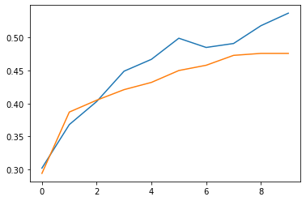

```python
plt.plot(train_acc_hist)
plt.plot(val_acc_hist)
```

#### Visulize the weight variable in the first layer.

Visualization of the intermediate weights can help you get an intuitive understanding of how the network works, especially in Convolutional Neural Networks (CNNs).

```python
from utils.display_funcs import visualize_pics
```

```
num of feature vectors: 100
```

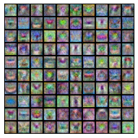

```python
weights = model.layer1.params[0]
pics = weights.reshape(3, 32, 32, -1).transpose(3, 1, 2, 0)
## visualization
visualize_pics(pics)
```

### Get test accuracy greater than 50%

For this part, you need to train a better two-layer net. The requirement is to get test accuracy better than 50%. If your accuracy is lower, for each 1% lower than 50%, you will lose 5 points.

Here are some recommended methods for improving the performance. Feel free to try any other method as you see fit.

1. Hyperparameter tuning: reg, hidden_dim, lr, learning_decay, num_epoch, batch_size, weight_scale.
2. Adjust training strategy: Randomly select a batch of samples rather than selecting them orderly.
3. Try new optimization methods: Now we are using SGD, you can try SGD with momentum, adam, etc.
4. Early-stopping.
5. Good (better) initial values for weights in the model.

A comparison between SGD and SGD with momentum.

- Stochastic gradient descent - SGD

  ```
    w = w - learning_rate * gradient
  ```

- SGD with momentum

  ```
    v = momentum*v + learning_rate * gradient
    w = w - v
  ```

**TODO**

```python
from utils.classifiers.twolayernet import TwoLayerNet
# Use previous layers to create a two layer neural network.
# Try several solutions and report the best performing one.
# input->(affine->activation)->(affine->softmax)->output
# The recommended activation function is ReLU. You can
# make a comparison with other activation functions to see
# the differences.
#
# You will need to execute code similar to below, using your parameter specs:
#    model = TwoLayerNet(input_dim=TBD, hidden_dim=TBD, num_classes=TBD, reg=TBD, weight_scale=TBD)
#    num_epoch = TBD
#    batch_size = TBD
#    lr = TBD
#    verbose = TBD
#    train_acc_hist, val_acc_hist = train(TBD)
#    test(TBD, TBD, TBD)
```

**SOLUTION (enter a new cell below):**

```python
# This one is with momentum.
model = TwoLayerNet(input_dim=3072, hidden_dim=256, num_classes=10, reg=1e-3, weight_scale=1e-2)
num_epoch = 50
batch_size = 256
lr = 1e-3
verbose = False
train_acc_hist, val_acc_hist = train(model, X_train, y_train, X_val, y_val, num_epoch=num_epoch, batch_size=batch_size, learning_rate=lr, verbose=verbose)
test(model, X_test, y_test)
```

```
number of batches for training: 191
epoch 1: valid acc = 0.18, new learning rate = 0.00095
epoch 2: valid acc = 0.302, new learning rate = 0.0009025
epoch 3: valid acc = 0.332, new learning rate = 0.000857375
epoch 4: valid acc = 0.381, new learning rate = 0.0008145062499999999
epoch 5: valid acc = 0.387, new learning rate = 0.0007737809374999998
epoch 6: valid acc = 0.429, new learning rate = 0.0007350918906249997
epoch 7: valid acc = 0.442, new learning rate = 0.0006983372960937497
epoch 8: valid acc = 0.455, new learning rate = 0.0006634204312890621
epoch 9: valid acc = 0.459, new learning rate = 0.000630249409724609
epoch 10: valid acc = 0.473, new learning rate = 0.0005987369392383785
epoch 11: valid acc = 0.475, new learning rate = 0.0005688000922764595
epoch 12: valid acc = 0.477, new learning rate = 0.0005403600876626365
epoch 13: valid acc = 0.489, new learning rate = 0.0005133420832795047
epoch 14: valid acc = 0.487, new learning rate = 0.00048767497911552944
epoch 15: valid acc = 0.495, new learning rate = 0.00046329123015975297
epoch 16: valid acc = 0.492, new learning rate = 0.0004401266686517653
epoch 17: valid acc = 0.516, new learning rate = 0.00041812033521917703
epoch 18: valid acc = 0.502, new learning rate = 0.00039721431845821814
epoch 19: valid acc = 0.513, new learning rate = 0.0003773536025353072
epoch 20: valid acc = 0.498, new learning rate = 0.0003584859224085418
epoch 21: valid acc = 0.511, new learning rate = 0.0003405616262881147
epoch 22: valid acc = 0.509, new learning rate = 0.00032353354497370894
epoch 23: valid acc = 0.509, new learning rate = 0.00030735686772502346
epoch 24: valid acc = 0.511, new learning rate = 0.00029198902433877225
epoch 25: valid acc = 0.519, new learning rate = 0.00027738957312183364
epoch 26: valid acc = 0.515, new learning rate = 0.0002635200944657419
epoch 27: valid acc = 0.51, new learning rate = 0.0002503440897424548
epoch 28: valid acc = 0.52, new learning rate = 0.00023782688525533205
epoch 29: valid acc = 0.524, new learning rate = 0.00022593554099256544
epoch 30: valid acc = 0.532, new learning rate = 0.00021463876394293716
epoch 31: valid acc = 0.522, new learning rate = 0.0002039068257457903
epoch 32: valid acc = 0.526, new learning rate = 0.00019371148445850077
epoch 33: valid acc = 0.514, new learning rate = 0.00018402591023557573
epoch 34: valid acc = 0.53, new learning rate = 0.00017482461472379692
epoch 35: valid acc = 0.511, new learning rate = 0.00016608338398760707
epoch 36: valid acc = 0.523, new learning rate = 0.0001577792147882267
epoch 37: valid acc = 0.53, new learning rate = 0.00014989025404881537
epoch 38: valid acc = 0.511, new learning rate = 0.00014239574134637458
epoch 39: valid acc = 0.526, new learning rate = 0.00013527595427905584
epoch 40: valid acc = 0.513, new learning rate = 0.00012851215656510304
epoch 41: valid acc = 0.508, new learning rate = 0.00012208654873684788
epoch 42: valid acc = 0.519, new learning rate = 0.00011598222130000548
epoch 43: valid acc = 0.518, new learning rate = 0.00011018311023500519
epoch 44: valid acc = 0.515, new learning rate = 0.00010467395472325493
epoch 45: valid acc = 0.508, new learning rate = 9.944025698709218e-05
epoch 46: valid acc = 0.506, new learning rate = 9.446824413773756e-05
epoch 47: valid acc = 0.502, new learning rate = 8.974483193085068e-05
epoch 48: valid acc = 0.521, new learning rate = 8.525759033430814e-05
epoch 49: valid acc = 0.51, new learning rate = 8.099471081759274e-05
epoch 50: valid acc = 0.513, new learning rate = 7.69449752767131e-05
test acc: 0.5114
```

```
0.5114
```

## plot training and validation accuracy of your best model

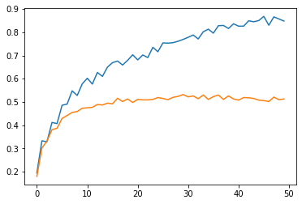

```python
plt.plot(train_acc_hist)
plt.plot(val_acc_hist)
```

**SOLUTION (enter a new cell below):**

```python
##  Visualize weights of the first layer
```

```python
W1 = model.layer1.params[0]
b1 = model.layer1.params[1]

print(W1.shape)
# Plot the W1
import matplotlib.cm as cm
plt.imshow(W1, cmap=cm.jet)
```

[output not shown]

```
(3072, 256)
```

```
(3072,)
```

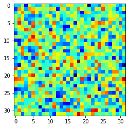

```python
# See the weights for the first hidden layer.
W_first_hidden = W1[:,0]
print(W_first_hidden.shape)
reshape_W = W_first_hidden.reshape(3,32,32)
# Example: Show the operation on first channel
plt.imshow(reshape_W[0], cmap=cm.jet)
```

### Save your best model in a dictionary

```python
## Create "save_model" folder if it does not exist
save_dir = "./save_models/"
if not os.path.exists(save_dir):
    os.makedirs(save_dir)

## Save your model
save_params = model.save_model()
with open("./save_models/best_model.pkl", "wb") as output_file:
    pickle.dump(save_params, output_file)
```

```python
## Load your model - FYI
#with open("./save_models/best_model.pkl", "rb") as input_file:
#    load_params = pickle.load(input_file)

#model.update_model(load_params)
```